# Projekt1

Frej,Olszewski,Piotrowski,Rutkowski

22 października 2015

Etap 1: wczytanie i obrobka danych, chcemy otrzymać złączoną tabelę z poszczególnymi genami i rodzajami raka.

```r
load("expression.cb1.rda")
load("expression.cb2.rda")
load("clinical.cb.rda")
```

Łączymy kolumny i zamieniamy nazwy kolumn, by były te same w obu tabelach.

```r
expression <- rbind(expression.cb1, expression.cb2)
clinical.cb[,1] <- gsub("\\-", "\\.", clinical.cb[,1])

expression_tmp <- t(expression[,-1])
expression_tmp <- as.data.frame(expression_tmp)
colnames(expression_tmp) <- expression[,1]
expression_tmp <- cbind(rownames(expression_tmp), expression_tmp)

colnames(expression_tmp)[1] <- "PatientID"
colnames(clinical.cb)[1] <- "PatientID"
```

Robimy “JOIN” tabel względem ID pacjenta

```r
merged_table <- merge(expression_tmp, clinical.cb[,c("PatientID", "X_cohort")], by="PatientID")
```

Czyścimy nazwy kolumn, by nie było błędów

```r
colnames(merged_table) <- gsub("\\?\\|","G", colnames(merged_table))
colnames(merged_table) <- paste("G", colnames(merged_table), sep="")
colnames(merged_table) <- gsub("\\-","", colnames(merged_table))
colnames(merged_table) <- gsub("\\,","", colnames(merged_table))
colnames(merged_table) <- gsub(" ","", colnames(merged_table))

merged_table[,"GX_cohort"] <- as.factor(merged_table[,"GX_cohort"])
```

Etap 2: teraz dla otrzymanej tabeli wykonujemy jednokierunkową analizę wariancji zobaczyć, które geny rozróżniają grupy rakowe

```r
formulas <- lapply(2:(ncol(merged_table)-1), function(i) {
  as.formula(paste(colnames(merged_table)[i],"GX_cohort", sep="~"))
}
)

#p_values <- unlist(lapply(formulas, function(i) {
#  summary(aov(i, data=merged_table))[[1]][["Pr(>F)"]][1]
#}))

load("p_values.Rdata")
```

Zobaczmy jakie dostalismy p-wartosci

```r
p_values_sorted_decr <- sort(p_values, decreasing = TRUE)
p_values_sorted_incr <- sort(p_values, decreasing = FALSE)

quantile(p_values,probs=(1:10)/10)
```

```
##           10%           20%           30%           40%           50%
##  0.000000e+00  0.000000e+00  0.000000e+00  0.000000e+00 1.084990e-312
##           60%           70%           80%           90%          100%
## 3.270656e-270 3.334162e-229 4.140169e-187 6.075081e-134  6.510925e-05
```

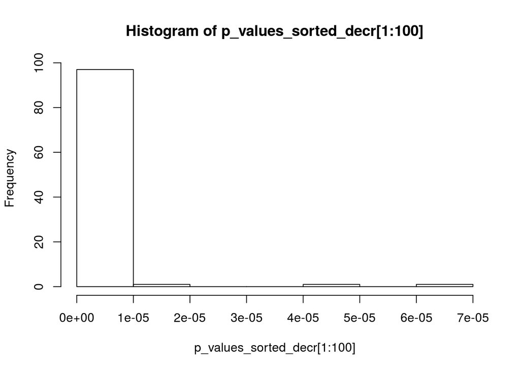

```r
hist(p_values_sorted_decr[1:100])
```

```r
head(p_values_sorted_decr,100)
```

```
##   [1] 6.510925e-05 4.927937e-05 1.507052e-05 3.631031e-06 1.941889e-06
##   [6] 1.601824e-06 1.116935e-06 1.020470e-06 6.552150e-08 4.242279e-08
##  [11] 2.467769e-08 8.764080e-09 6.559790e-10 2.241040e-10 2.006108e-10
##  [16] 3.043136e-11 9.623565e-12 2.873201e-12 2.154967e-12 2.027177e-12
##  [21] 6.306557e-13 2.883254e-13 1.003961e-13 4.174969e-14 4.075983e-14
##  [26] 3.482820e-14 2.613189e-14 2.294445e-14 1.811144e-14 1.125795e-14
##  [31] 6.386052e-15 3.673021e-15 4.481585e-16 1.048537e-16 8.839973e-17
##  [36] 5.266865e-17 4.838166e-18 2.546610e-19 1.701916e-19 1.175332e-19
##  [41] 5.773392e-20 5.728416e-20 3.039986e-20 2.894235e-20 2.070472e-20
##  [46] 1.744658e-20 8.224956e-21 4.578475e-21 1.013152e-21 7.931577e-22
##  [51] 5.394948e-22 4.176489e-22 1.147315e-22 6.688683e-23 4.376556e-23
##  [56] 3.430375e-23 2.149907e-23 5.040762e-24 3.999814e-24 2.589327e-24
##  [61] 2.023985e-24 5.317866e-25 4.392035e-25 2.675805e-25 2.227534e-25
##  [66] 1.168771e-25 2.566979e-26 2.111635e-26 1.066597e-26 8.674867e-27
##  [71] 7.695510e-27 6.999422e-27 5.426271e-27 1.448407e-27 1.153574e-27
##  [76] 5.921548e-28 1.105894e-28 4.873686e-29 4.286374e-29 1.854389e-29
##  [81] 7.186877e-30 7.054308e-30 5.457359e-30 4.749566e-30 4.428465e-30
##  [86] 1.831428e-30 1.464456e-30 3.632677e-31 3.456287e-31 2.481151e-31
##  [91] 1.182618e-31 4.537251e-32 2.812501e-32 2.777613e-32 2.093463e-32
##  [96] 1.096171e-32 8.230251e-33 2.467475e-33 2.298133e-34 9.193670e-35
```

```r
head(p_values_sorted_incr,100)
```

```
##   [1] 0 0 0 0 0 0 0 0 0 0 0 0 0 0 0 0 0 0 0 0 0 0 0 0 0 0 0 0 0 0 0 0 0 0 0
##  [36] 0 0 0 0 0 0 0 0 0 0 0 0 0 0 0 0 0 0 0 0 0 0 0 0 0 0 0 0 0 0 0 0 0 0 0
##  [71] 0 0 0 0 0 0 0 0 0 0 0 0 0 0 0 0 0 0 0 0 0 0 0 0 0 0 0 0 0 0
```

```r
length(which(p_values==0))
```

```
## [1] 7641
```

Widzimy, że dużo p-wartości jest bardzo małych, a ok połowa wychodzi poza zakres zmiennej. Zobaczmy czy założenia ANOVY są spełnione

```r
equal_dev_fligner <- readRDS("fligner_p_value.rds")
#start <- proc.time()
#N <- length(formulas)
#equal_dev_fligner <- sapply(1:N, function(j){
#  fligner.test(formulas[[j]],data=merged_table)$p.value
#})
#proc.time()-start
#saveRDS(equal_dev_fligner,"fligner_p_value.rds")
#equal_dev_fligner <- readRDS("fligner_p_value.rds")

gen_equal_dev <- which(equal_dev_fligner>0.01)
length(gen_equal_dev) # tylko 93!
```

```
## [1] 93
```

Widzimy, że tylko 93 geny przeszły test Flignera na poziomie istiotności 0.01! Zobaczmy jak wypadnie test Shapiro-Wilka normalności reszt

```r
#start <- proc.time()
#N <- length(formulas)
#shapiro_p_value <- sapply(1:N, function(j){
#  shapiro.test(lm(formulas[[j]],data=merged_table)$residuals)$p.value
#})
#proc.time()-start

shapiro_p_value <-readRDS("shapiro_p_value.rds")
```

Przeprowadzamy dokładniejszą analizę dla genów, które przeszły testy

```r
sum(equal_dev_fligner>0.01)
```

```
## [1] 93
```

```r
sum(shapiro_p_value>0.01)
```

```
## [1] 248
```

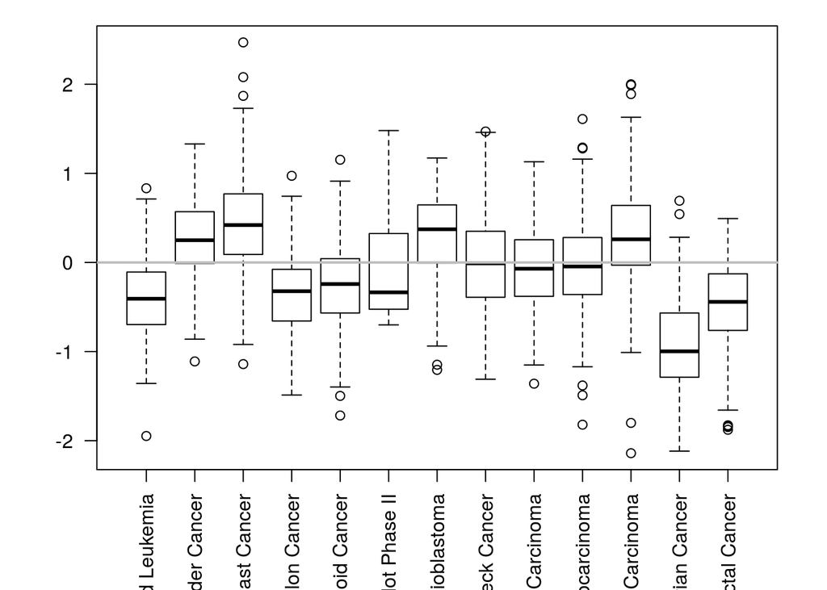

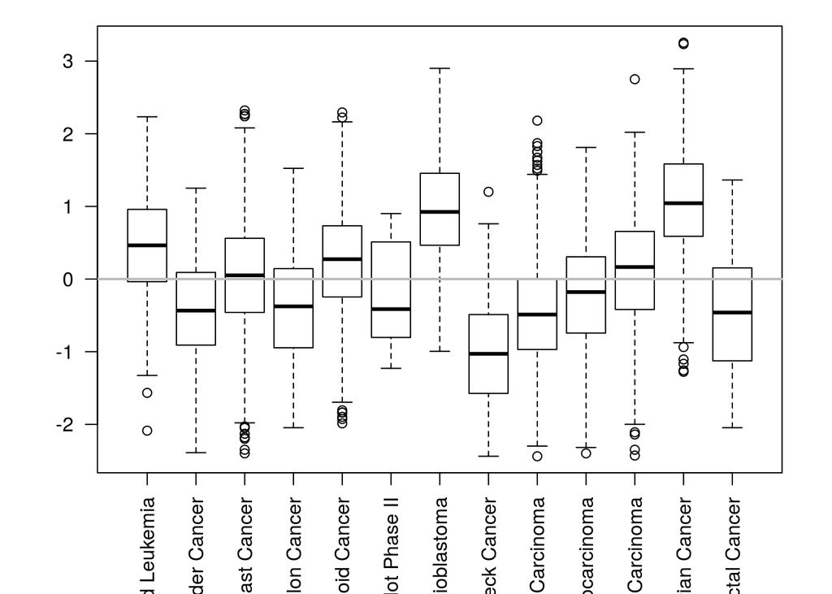

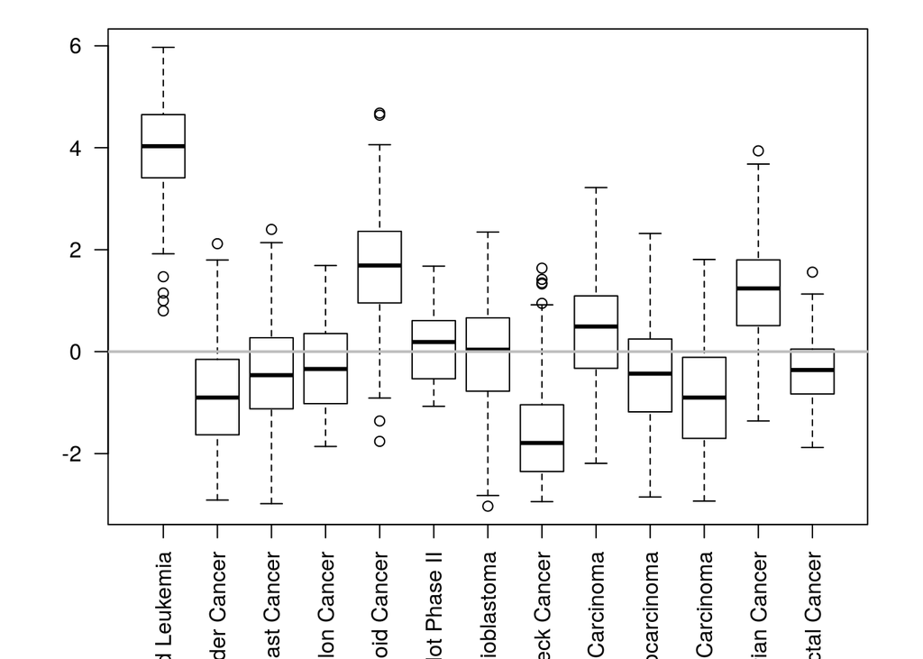

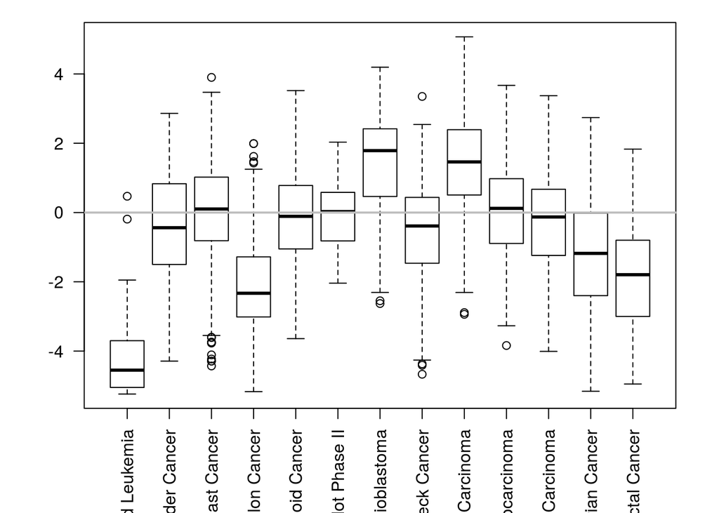

```r
gens_model <-(equal_dev_fligner>0.01)  & (shapiro_p_value>0.01)

gens_id <- which(gens_model)

par(mar=c(5.1,4.1,1.1,2.1))
par(mfrow=c(1,1))

for(j in 1:length(gens_id)){
  boxplot(formulas[[gens_id[j]]], data=merged_table,las=2)
  abline(h=0, col='grey', lwd=2)
}
```

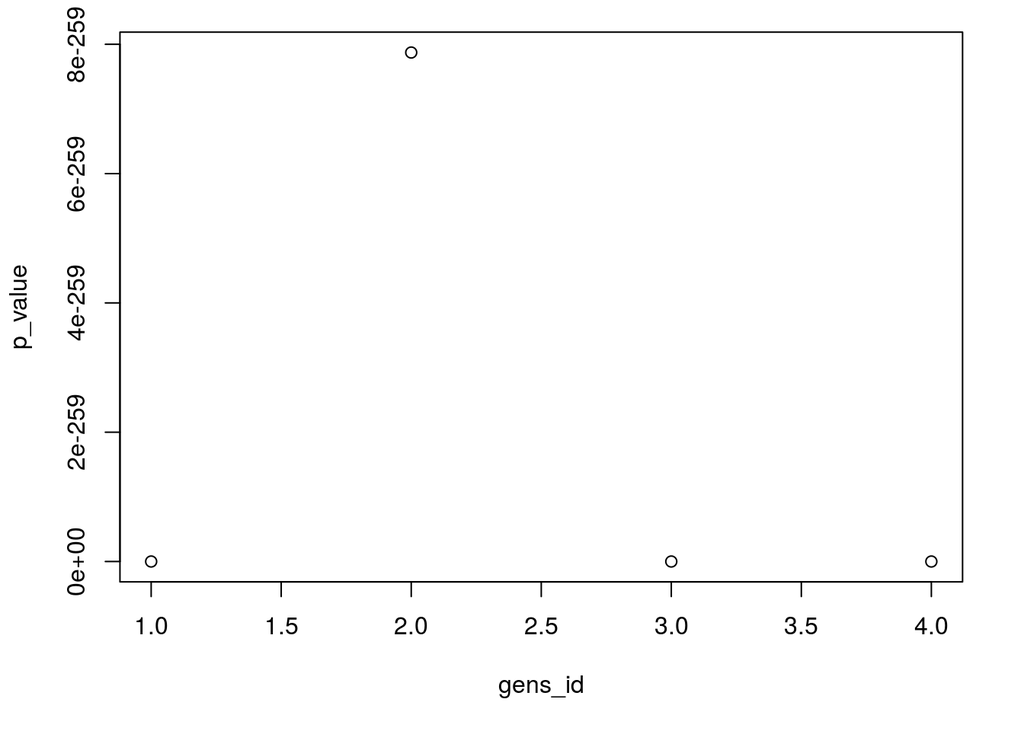

```r
#as.formula(colnames(merged_table)[gen_equal_dev[j]+1])
PPV <- lapply(1:length(gens_id),function(j){
  pairwise.t.test(merged_table[,gens_id[j]],merged_table$'GX_cohort')
})


plot(p_values[gens_id],xlab="gens_id",ylab="p_value")
```

Widzimy, że są tylko 4 geny spełniające założenia modelu, dla każdego z nich możemy zaobserwować wyraźną różnicę między średnimi dla różnych rodzajów raka

Etap 3: widzimy, że nie możemy zastosować ANOVY dla wszystkich genów, wykonamy więc nieparametryczny test Kruskala, dla którego nie potrzebujemy tak mocnych założeń

```r
#start <- proc.time()
#N <- length(formulas)
#kruskal_p_value <- sapply(1:N, function(j){
#  kruskal.test(formulas[[j]],data=merged_table)$p.value
#})
#proc.time()-start


kruskal_p_value <- readRDS("kruskal_p_value.rds")
sum(kruskal_p_value>0.001)
```

```
## [1] 2
```

```r
head(sort(kruskal_p_value[gen_equal_dev],decreasing=T),10)
```

```
##  [1] 3.416463e-03 1.286956e-04 9.257433e-05 5.909689e-05 1.490232e-05
##  [6] 1.097632e-05 3.720130e-15 1.558148e-15 4.401524e-17 5.456790e-19
```